# Part 2

Author

Albert Rapp

Published

August 28, 2024

# Part 2

## Lesson 1

Overview of different formats for the same database. Those are csv, csv with header, csv semicolon separator, tsv space separator, csv metadata, excel files, json files, which are annoying looking

## Lesson 2: Same data in in different formats

Loading csv files. It is recommended that you Rstudio project which set up the relative paths. You don’t need to use here::here(path)

```r
library(tidyverse)


read_csv('data/Part_2/02_exibble.csv')
```

```
# A tibble: 80 × 8
   fruit     letter   hrs   min dates               missing_numbers missing_NULL
   <chr>     <chr>  <dbl> <dbl> <dttm>                        <dbl> <chr>
 1 apple     n        482    14 2024-07-16 02:14:00             751 (null)
 2 apricot   d        129    38 2024-07-01 09:38:00             657 948
 3 avocado   m        248    42 2024-07-06 08:42:00              NA 1065
 4 banana    z        985    23 2024-08-06 01:23:00              34 109
 5 bell pep… s         34    45 2024-06-27 10:45:00              NA (null)
 6 bilberry  s        337    23 2024-07-10 01:23:00              NA 1006
 7 blackber… a        186    58 2024-07-03 18:58:00              NA (null)
 8 blackcur… t       1219    46 2024-08-15 19:46:00              NA (null)
 9 blood or… w       1061    54 2024-08-09 05:54:00              NA 289
10 blueberry y        274    28 2024-07-07 10:28:00              NA (null)
# ℹ 70 more rows
# ℹ 1 more variable: missing_dates <chr>
```

```r
getwd()
```

```
[1] "/Users/albertofcabrera/Documents/R-books/3MW(Albert Rapp)/r_data_cleanning_master_class"
```

## Lesson 3: Read standard csv-files

### How to read csv files with no headers.

Loading it directly the first row will be interpreted as the names of the columns. This is not what we want. Instead we need to tell `read_csv()` function that there are no column names.

By default, csv will assign generic column names.

```r
read_csv('data/Part_2/01_exibble_no_headers.csv',
         col_names = FALSE)
```

```
# A tibble: 80 × 8
   X1           X2       X3    X4 X5                     X6 X7     X8
   <chr>        <chr> <dbl> <dbl> <dttm>              <dbl> <chr>  <chr>
 1 apple        n       482    14 2024-07-16 02:14:00   751 (null) 2024-07-16 0…
 2 apricot      d       129    38 2024-07-01 09:38:00   657 948    Unknown
 3 avocado      m       248    42 2024-07-06 08:42:00    NA 1065   2024-07-06 0…
 4 banana       z       985    23 2024-08-06 01:23:00    34 109    2024-08-06 0…
 5 bell pepper  s        34    45 2024-06-27 10:45:00    NA (null) 2024-06-27 1…
 6 bilberry     s       337    23 2024-07-10 01:23:00    NA 1006   2024-07-10 0…
 7 blackberry   a       186    58 2024-07-03 18:58:00    NA (null) 2024-07-03 1…
 8 blackcurrant t      1219    46 2024-08-15 19:46:00    NA (null) 2024-08-15 1…
 9 blood orange w      1061    54 2024-08-09 05:54:00    NA 289    2024-08-09 0…
10 blueberry    y       274    28 2024-07-07 10:28:00    NA (null) 2024-07-07 1…
# ℹ 70 more rows
```

Instead, we can create a vector with the column names

```r
desired_colnames <-  c("fuit",
                       "letter",
                       "hrs",
                       "min",
                       "dates",
                       "missing_numbers",
                       "missing_NULL",
                       "missing_dates")

read_csv('data/Part_2/01_exibble_no_headers.csv',
         col_names = desired_colnames)
```

```
# A tibble: 80 × 8
   fuit      letter   hrs   min dates               missing_numbers missing_NULL
   <chr>     <chr>  <dbl> <dbl> <dttm>                        <dbl> <chr>
 1 apple     n        482    14 2024-07-16 02:14:00             751 (null)
 2 apricot   d        129    38 2024-07-01 09:38:00             657 948
 3 avocado   m        248    42 2024-07-06 08:42:00              NA 1065
 4 banana    z        985    23 2024-08-06 01:23:00              34 109
 5 bell pep… s         34    45 2024-06-27 10:45:00              NA (null)
 6 bilberry  s        337    23 2024-07-10 01:23:00              NA 1006
 7 blackber… a        186    58 2024-07-03 18:58:00              NA (null)
 8 blackcur… t       1219    46 2024-08-15 19:46:00              NA (null)
 9 blood or… w       1061    54 2024-08-09 05:54:00              NA 289
10 blueberry y        274    28 2024-07-07 10:28:00              NA (null)
# ℹ 70 more rows
# ℹ 1 more variable: missing_dates <chr>
```

### Reading a metadata csv file.

It displays a message with illegible data.

```r
read_csv("data/Part_2/05_exibble_with_metadata.csv")
```

```
# A tibble: 82 × 1
   `This file was produced with R`
   <chr>
 1 sep=;
 2 fruit,letter,hrs,min,dates,missing_numbers,missing_NULL,missing_dates
 3 apple,n,482,14,2024-07-16T02:14:00Z,751,(null),2024-07-16 02:14:00
 4 apricot,d,129,38,2024-07-01T09:38:00Z,657,948,Unknown
 5 avocado,m,248,42,2024-07-06T08:42:00Z,NA,1065,2024-07-06 08:42:00
 6 banana,z,985,23,2024-08-06T01:23:00Z,34,109,2024-08-06 01:23:00
 7 bell pepper,s,34,45,2024-06-27T10:45:00Z,NA,(null),2024-06-27 10:45:00
 8 bilberry,s,337,23,2024-07-10T01:23:00Z,NA,1006,2024-07-10 01:23:00
 9 blackberry,a,186,58,2024-07-03T18:58:00Z,NA,(null),2024-07-03 18:58:00
10 blackcurrant,t,1219,46,2024-08-15T19:46:00Z,NA,(null),2024-08-15 19:46:00
# ℹ 72 more rows
```

We need to skip the first two rows, which are not relevant. And now the file is correctly displayed.

```r
read_csv("data/Part_2/05_exibble_with_metadata.csv",
         skip = 2)
```

```
# A tibble: 80 × 8
   fruit     letter   hrs   min dates               missing_numbers missing_NULL
   <chr>     <chr>  <dbl> <dbl> <dttm>                        <dbl> <chr>
 1 apple     n        482    14 2024-07-16 02:14:00             751 (null)
 2 apricot   d        129    38 2024-07-01 09:38:00             657 948
 3 avocado   m        248    42 2024-07-06 08:42:00              NA 1065
 4 banana    z        985    23 2024-08-06 01:23:00              34 109
 5 bell pep… s         34    45 2024-06-27 10:45:00              NA (null)
 6 bilberry  s        337    23 2024-07-10 01:23:00              NA 1006
 7 blackber… a        186    58 2024-07-03 18:58:00              NA (null)
 8 blackcur… t       1219    46 2024-08-15 19:46:00              NA (null)
 9 blood or… w       1061    54 2024-08-09 05:54:00              NA 289
10 blueberry y        274    28 2024-07-07 10:28:00              NA (null)
# ℹ 70 more rows
# ℹ 1 more variable: missing_dates <chr>
```

### Read csv files in European format

Problem the first row has the name of the variables, but they are not recognized because of the use of “;” as delimiter. You need to replace the `read_csv()`function with the `read_csv2()`function.

```r
read_csv2("data/Part_2/03_exibble_european.csv")
```

```
# A tibble: 80 × 8
   fruit     letter   hrs   min dates               missing_numbers missing_NULL
   <chr>     <chr>  <dbl> <dbl> <dttm>                        <dbl> <chr>
 1 apple     n        482    14 2024-07-16 02:14:00             751 (null)
 2 apricot   d        129    38 2024-07-01 09:38:00             657 948
 3 avocado   m        248    42 2024-07-06 08:42:00              NA 1065
 4 banana    z        985    23 2024-08-06 01:23:00              34 109
 5 bell pep… s         34    45 2024-06-27 10:45:00              NA (null)
 6 bilberry  s        337    23 2024-07-10 01:23:00              NA 1006
 7 blackber… a        186    58 2024-07-03 18:58:00              NA (null)
 8 blackcur… t       1219    46 2024-08-15 19:46:00              NA (null)
 9 blood or… w       1061    54 2024-08-09 05:54:00              NA 289
10 blueberry y        274    28 2024-07-07 10:28:00              NA (null)
# ℹ 70 more rows
# ℹ 1 more variable: missing_dates <chr>
```

### Reading files with line breaks

RStudio reads this file as having two columns. Reading the quote file that appears to be connected with the line_break file

```r
read_csv("data/Part_2/09_line_break.csv")
```

```
# A tibble: 1 × 2
  text                                     num
  <chr>                                  <dbl>
1 "This is some text\nwith a line break"     1
```

```r
here::here()
```

```
[1] "/Users/albertofcabrera/Documents/R-books/3MW(Albert Rapp)/r_data_cleanning_master_class"
```

```r
read_csv("data/Part_2/10_quote.csv")
```

```
# A tibble: 1 × 2
  text                                                  num
  <chr>                                               <dbl>
1 "This is some text with a \\quote of something\\\""     1
```

Instead, we need to use the `read_delim()` function. And we need to specify we want as a delimiter a `,`.

```r
read_delim("data/Part_2/10_quote.csv",
           delim = ',',
           escape_backslash = TRUE)
```

```
# A tibble: 1 × 2
  text                                                num
  <chr>                                             <dbl>
1 "This is some text with a \"quote of something\""     1
```

```r
#Another option

read_delim("data/Part_2/11_quote_doubled.csv",
           delim = ',',
           escape_double = TRUE)
```

```
# A tibble: 1 × 2
  text                                                num
  <chr>                                             <dbl>
1 "This is some text with a \"quote of something\""     1
```

## Lesson 4: Reading tsv and txt files

### Loading tsv files which have a separated value

```r
read_tsv('data/Part_2/04_exibble.tsv')
```

```
# A tibble: 80 × 8
   fruit     letter   hrs   min dates               missing_numbers missing_NULL
   <chr>     <chr>  <dbl> <dbl> <dttm>                        <dbl> <chr>
 1 apple     n        482    14 2024-07-16 02:14:00             751 (null)
 2 apricot   d        129    38 2024-07-01 09:38:00             657 948
 3 avocado   m        248    42 2024-07-06 08:42:00              NA 1065
 4 banana    z        985    23 2024-08-06 01:23:00              34 109
 5 bell pep… s         34    45 2024-06-27 10:45:00              NA (null)
 6 bilberry  s        337    23 2024-07-10 01:23:00              NA 1006
 7 blackber… a        186    58 2024-07-03 18:58:00              NA (null)
 8 blackcur… t       1219    46 2024-08-15 19:46:00              NA (null)
 9 blood or… w       1061    54 2024-08-09 05:54:00              NA 289
10 blueberry y        274    28 2024-07-07 10:28:00              NA (null)
# ℹ 70 more rows
# ℹ 1 more variable: missing_dates <chr>
```

### Loading arbitrary text files

```r
read_delim('data/Part_2/12_weird_delimiter.txt',
           delim = '|')
```

```
# A tibble: 80 × 8
   fruit     letter   hrs   min dates               missing_numbers missing_NULL
   <chr>     <chr>  <dbl> <dbl> <dttm>                        <dbl> <chr>
 1 apple     n        482    14 2024-07-16 02:14:00             751 (null)
 2 apricot   d        129    38 2024-07-01 09:38:00             657 948
 3 avocado   m        248    42 2024-07-06 08:42:00              NA 1065
 4 banana    z        985    23 2024-08-06 01:23:00              34 109
 5 bell pep… s         34    45 2024-06-27 10:45:00              NA (null)
 6 bilberry  s        337    23 2024-07-10 01:23:00              NA 1006
 7 blackber… a        186    58 2024-07-03 18:58:00              NA (null)
 8 blackcur… t       1219    46 2024-08-15 19:46:00              NA (null)
 9 blood or… w       1061    54 2024-08-09 05:54:00              NA 289
10 blueberry y        274    28 2024-07-07 10:28:00              NA (null)
# ℹ 70 more rows
# ℹ 1 more variable: missing_dates <chr>
```

## Lesson 5: Reading Excel Files

One package useful for reading excel files is `oepnxls`. However, the data frame looks weird. This is why we transform it into tibble.

```r
library(openxlsx)

openxlsx::read.xlsx('data/Part_2/06_exibble.xlsx') |>
  as_tibble()
```

```
# A tibble: 80 × 8
   fruit    letter   hrs   min  dates missing_numbers missing_NULL missing_dates
   <chr>    <chr>  <dbl> <dbl>  <dbl>           <dbl> <chr>        <chr>
 1 apple    n        482    14 45489.             751 (null)       2024-07-16 0…
 2 apricot  d        129    38 45474.             657 948          Unknown
 3 avocado  m        248    42 45479.              NA 1065         2024-07-06 0…
 4 banana   z        985    23 45510.              34 109          2024-08-06 0…
 5 bell pe… s         34    45 45470.              NA (null)       2024-06-27 1…
 6 bilberry s        337    23 45483.              NA 1006         2024-07-10 0…
 7 blackbe… a        186    58 45477.              NA (null)       2024-07-03 1…
 8 blackcu… t       1219    46 45520.              NA (null)       2024-08-15 1…
 9 blood o… w       1061    54 45513.              NA 289          2024-08-09 0…
10 blueber… y        274    28 45480.              NA (null)       2024-07-07 1…
# ℹ 70 more rows
```

However, the column with dates is not treated as a date but with a weird number. Consequently we could recode the variable dates as a date format using `lubridate`

```r
library(lubridate)

openxlsx::read.xlsx('data/Part_2/06_exibble.xlsx') |>
  as_tibble() |>
  mutate(dates = as_date(dates))
```

```
# A tibble: 80 × 8
   fruit        letter   hrs   min dates      missing_numbers missing_NULL
   <chr>        <chr>  <dbl> <dbl> <date>               <dbl> <chr>
 1 apple        n        482    14 2094-07-18             751 (null)
 2 apricot      d        129    38 2094-07-03             657 948
 3 avocado      m        248    42 2094-07-08              NA 1065
 4 banana       z        985    23 2094-08-08              34 109
 5 bell pepper  s         34    45 2094-06-29              NA (null)
 6 bilberry     s        337    23 2094-07-12              NA 1006
 7 blackberry   a        186    58 2094-07-05              NA (null)
 8 blackcurrant t       1219    46 2094-08-17              NA (null)
 9 blood orange w       1061    54 2094-08-11              NA 289
10 blueberry    y        274    28 2094-07-09              NA (null)
# ℹ 70 more rows
# ℹ 1 more variable: missing_dates <chr>
```

We could also use the `janitor` package to transfer dates into a date format

```r
openxlsx::read.xlsx('data/Part_2/06_exibble.xlsx') |>
  as_tibble() |>
  mutate(dates = janitor::excel_numeric_to_date(dates))
```

```
# A tibble: 80 × 8
   fruit        letter   hrs   min dates      missing_numbers missing_NULL
   <chr>        <chr>  <dbl> <dbl> <date>               <dbl> <chr>
 1 apple        n        482    14 2024-07-16             751 (null)
 2 apricot      d        129    38 2024-07-01             657 948
 3 avocado      m        248    42 2024-07-06              NA 1065
 4 banana       z        985    23 2024-08-06              34 109
 5 bell pepper  s         34    45 2024-06-27              NA (null)
 6 bilberry     s        337    23 2024-07-10              NA 1006
 7 blackberry   a        186    58 2024-07-03              NA (null)
 8 blackcurrant t       1219    46 2024-08-15              NA (null)
 9 blood orange w       1061    54 2024-08-09              NA 289
10 blueberry    y        274    28 2024-07-07              NA (null)
# ℹ 70 more rows
# ℹ 1 more variable: missing_dates <chr>
```

## Lesson 6: Reading JSON files

JSON files require a particular package: `jsonlite` package. Notice that json files have a nested structure. Notice that json file contains [[80]].

The `str()` function comes handy. It displays the list signifying rows. Each row displays the names of the columns, and their contents.

### Using glimpse

You can also use the `glimpse` function.

```r
library(jsonlite)

jsonlite::read_json('data/Part_2/07_exibble.json') |>
  str()
```

```
List of 80
 $ :List of 8
  ..$ fruit          : chr "apple"
  ..$ letter         : chr "n"
  ..$ hrs            : int 482
  ..$ min            : int 14
  ..$ dates          : chr "2024-07-16 02:14:00"
  ..$ missing_numbers: int 751
  ..$ missing_NULL   : chr "(null)"
  ..$ missing_dates  : chr "2024-07-16 02:14:00"
 $ :List of 8
  ..$ fruit          : chr "apricot"
  ..$ letter         : chr "d"
  ..$ hrs            : int 129
  ..$ min            : int 38
  ..$ dates          : chr "2024-07-01 09:38:00"
  ..$ missing_numbers: int 657
  ..$ missing_NULL   : chr "948"
  ..$ missing_dates  : chr "Unknown"
 $ :List of 7
  ..$ fruit        : chr "avocado"
  ..$ letter       : chr "m"
  ..$ hrs          : int 248
  ..$ min          : int 42
  ..$ dates        : chr "2024-07-06 08:42:00"
  ..$ missing_NULL : chr "1065"
  ..$ missing_dates: chr "2024-07-06 08:42:00"
 $ :List of 8
  ..$ fruit          : chr "banana"
  ..$ letter         : chr "z"
  ..$ hrs            : int 985
  ..$ min            : int 23
  ..$ dates          : chr "2024-08-06 01:23:00"
  ..$ missing_numbers: int 34
  ..$ missing_NULL   : chr "109"
  ..$ missing_dates  : chr "2024-08-06 01:23:00"
 $ :List of 7
  ..$ fruit        : chr "bell pepper"
  ..$ letter       : chr "s"
  ..$ hrs          : int 34
```

[output cut: 625 more lines]

```
  ..$ letter         : chr "z"
  ..$ hrs            : int 1019
  ..$ min            : int 55
  ..$ dates          : chr "2024-08-07 11:55:00"
  ..$ missing_numbers: int 1147
  ..$ missing_NULL   : chr "(null)"
  ..$ missing_dates  : chr "2024-08-07 11:55:00"
 $ :List of 7
  ..$ fruit        : chr "watermelon"
  ..$ letter       : chr "y"
  ..$ hrs          : int 568
  ..$ min          : int 0
  ..$ dates        : chr "2024-07-19 16:00:00"
  ..$ missing_NULL : chr "(null)"
  ..$ missing_dates: chr "2024-07-19 16:00:00"
```

Using glimpse function to describe the organization of the json files

```r
library(jsonlite)

jsonlite::read_json('data/Part_2/07_exibble.json') |>
  glimpse()
```

```
List of 80
 $ :List of 8
  ..$ fruit          : chr "apple"
  ..$ letter         : chr "n"
  ..$ hrs            : int 482
  ..$ min            : int 14
  ..$ dates          : chr "2024-07-16 02:14:00"
  ..$ missing_numbers: int 751
  ..$ missing_NULL   : chr "(null)"
  ..$ missing_dates  : chr "2024-07-16 02:14:00"
 $ :List of 8
  ..$ fruit          : chr "apricot"
  ..$ letter         : chr "d"
  ..$ hrs            : int 129
  ..$ min            : int 38
  ..$ dates          : chr "2024-07-01 09:38:00"
  ..$ missing_numbers: int 657
  ..$ missing_NULL   : chr "948"
  ..$ missing_dates  : chr "Unknown"
 $ :List of 7
  ..$ fruit        : chr "avocado"
  ..$ letter       : chr "m"
  ..$ hrs          : int 248
  ..$ min          : int 42
  ..$ dates        : chr "2024-07-06 08:42:00"
  ..$ missing_NULL : chr "1065"
  ..$ missing_dates: chr "2024-07-06 08:42:00"
 $ :List of 8
  ..$ fruit          : chr "banana"
  ..$ letter         : chr "z"
  ..$ hrs            : int 985
  ..$ min            : int 23
  ..$ dates          : chr "2024-08-06 01:23:00"
  ..$ missing_numbers: int 34
  ..$ missing_NULL   : chr "109"
  ..$ missing_dates  : chr "2024-08-06 01:23:00"
 $ :List of 7
  ..$ fruit        : chr "bell pepper"
  ..$ letter       : chr "s"
  ..$ hrs          : int 34
```

[output cut: 625 more lines]

```
  ..$ letter         : chr "z"
  ..$ hrs            : int 1019
  ..$ min            : int 55
  ..$ dates          : chr "2024-08-07 11:55:00"
  ..$ missing_numbers: int 1147
  ..$ missing_NULL   : chr "(null)"
  ..$ missing_dates  : chr "2024-08-07 11:55:00"
 $ :List of 7
  ..$ fruit        : chr "watermelon"
  ..$ letter       : chr "y"
  ..$ hrs          : int 568
  ..$ min          : int 0
  ..$ dates        : chr "2024-07-19 16:00:00"
  ..$ missing_NULL : chr "(null)"
  ..$ missing_dates: chr "2024-07-19 16:00:00"
```

### Using bind_rows() function

Use bind rows function to find together the different rows that make up the json file. It allows us to create a nice tibble file.

```r
library(jsonlite)

jsonlite::read_json('data/Part_2/07_exibble.json') |>
  bind_rows()
```

```
# A tibble: 80 × 8
   fruit     letter   hrs   min dates missing_numbers missing_NULL missing_dates
   <chr>     <chr>  <int> <int> <chr>           <int> <chr>        <chr>
 1 apple     n        482    14 2024…             751 (null)       2024-07-16 0…
 2 apricot   d        129    38 2024…             657 948          Unknown
 3 avocado   m        248    42 2024…              NA 1065         2024-07-06 0…
 4 banana    z        985    23 2024…              34 109          2024-08-06 0…
 5 bell pep… s         34    45 2024…              NA (null)       2024-06-27 1…
 6 bilberry  s        337    23 2024…              NA 1006         2024-07-10 0…
 7 blackber… a        186    58 2024…              NA (null)       2024-07-03 1…
 8 blackcur… t       1219    46 2024…              NA (null)       2024-08-15 1…
 9 blood or… w       1061    54 2024…              NA 289          2024-08-09 0…
10 blueberry y        274    28 2024…              NA (null)       2024-07-07 1…
# ℹ 70 more rows
```

### GLIMPSE and bind_rows functions

You can use both of them to describe the components of the file. And, then create the tibble file

```
List of 80
 $ :List of 8
  ..$ fruit          : chr "apple"
  ..$ letter         : chr "n"
  ..$ hrs            : int 482
  ..$ min            : int 14
  ..$ dates          : chr "2024-07-16 02:14:00"
  ..$ missing_numbers: int 751
  ..$ missing_NULL   : chr "(null)"
  ..$ missing_dates  : chr "2024-07-16 02:14:00"
 $ :List of 8
  ..$ fruit          : chr "apricot"
  ..$ letter         : chr "d"
  ..$ hrs            : int 129
  ..$ min            : int 38
  ..$ dates          : chr "2024-07-01 09:38:00"
  ..$ missing_numbers: int 657
  ..$ missing_NULL   : chr "948"
  ..$ missing_dates  : chr "Unknown"
 $ :List of 7
  ..$ fruit        : chr "avocado"
  ..$ letter       : chr "m"
  ..$ hrs          : int 248
  ..$ min          : int 42
  ..$ dates        : chr "2024-07-06 08:42:00"
  ..$ missing_NULL : chr "1065"
  ..$ missing_dates: chr "2024-07-06 08:42:00"
 $ :List of 8
  ..$ fruit          : chr "banana"
  ..$ letter         : chr "z"
  ..$ hrs            : int 985
  ..$ min            : int 23
  ..$ dates          : chr "2024-08-06 01:23:00"
  ..$ missing_numbers: int 34
  ..$ missing_NULL   : chr "109"
  ..$ missing_dates  : chr "2024-08-06 01:23:00"
 $ :List of 7
  ..$ fruit        : chr "bell pepper"
  ..$ letter       : chr "s"
  ..$ hrs          : int 34
```

[output cut: 625 more lines]

```
  ..$ letter         : chr "z"
  ..$ hrs            : int 1019
  ..$ min            : int 55
  ..$ dates          : chr "2024-08-07 11:55:00"
  ..$ missing_numbers: int 1147
  ..$ missing_NULL   : chr "(null)"
  ..$ missing_dates  : chr "2024-08-07 11:55:00"
 $ :List of 7
  ..$ fruit        : chr "watermelon"
  ..$ letter       : chr "y"
  ..$ hrs          : int 568
  ..$ min          : int 0
  ..$ dates        : chr "2024-07-19 16:00:00"
  ..$ missing_NULL : chr "(null)"
  ..$ missing_dates: chr "2024-07-19 16:00:00"
```

```
# A tibble: 80 × 8
   fruit     letter   hrs   min dates missing_numbers missing_NULL missing_dates
   <chr>     <chr>  <int> <int> <chr>           <int> <chr>        <chr>
 1 apple     n        482    14 2024…             751 (null)       2024-07-16 0…
 2 apricot   d        129    38 2024…             657 948          Unknown
 3 avocado   m        248    42 2024…              NA 1065         2024-07-06 0…
 4 banana    z        985    23 2024…              34 109          2024-08-06 0…
 5 bell pep… s         34    45 2024…              NA (null)       2024-06-27 1…
 6 bilberry  s        337    23 2024…              NA 1006         2024-07-10 0…
 7 blackber… a        186    58 2024…              NA (null)       2024-07-03 1…
 8 blackcur… t       1219    46 2024…              NA (null)       2024-08-15 1…
 9 blood or… w       1061    54 2024…              NA 289          2024-08-09 0…
10 blueberry y        274    28 2024…              NA (null)       2024-07-07 1…
# ℹ 70 more rows
```

```
Rows: 80
Columns: 8
$ fruit           <chr> "apple", "apricot", "avocado", "banana", "bell pepper"…
$ letter          <chr> "n", "d", "m", "z", "s", "s", "a", "t", "w", "y", "n",…
$ hrs             <int> 482, 129, 248, 985, 34, 337, 186, 1219, 1061, 274, 118…
$ min             <int> 14, 38, 42, 23, 45, 23, 58, 46, 54, 28, 18, 28, 31, 39…
$ dates           <chr> "2024-07-16 02:14:00", "2024-07-01 09:38:00", "2024-07…
$ missing_numbers <int> 751, 657, NA, 34, NA, NA, NA, NA, NA, NA, 283, NA, 289…
$ missing_NULL    <chr> "(null)", "948", "1065", "109", "(null)", "1006", "(nu…
$ missing_dates   <chr> "2024-07-16 02:14:00", "Unknown", "2024-07-06 08:42:00…
```

### Reading a second json file

```r
library(jsonlite)
jsonlite::read_json('data/Part_2/08_nested_example.json') |>
  glimpse()
```

```
List of 2
 $ fruit      :List of 1
  ..$ : chr "some_fruit"
 $ information:List of 3
  ..$ origin  :List of 2
  .. ..$ country:List of 2
  .. ..$ season :List of 2
  ..$ price   :List of 1
  .. ..$ : num 432
  ..$ currency:List of 1
  .. ..$ : chr "EUR"
```

Extracting information from `08_nested_example/json` using the `pluck()` function, which can go to a particular column. In this case, we want to go to the information column and then the origin column.

```
List of 2
 $ country:List of 2
  ..$ : chr "Some country"
  ..$ : chr "Other country"
 $ season :List of 2
  ..$ : chr "Summer"
  ..$ : chr "Winter"
```

### Next we could pass this information as tibble

We need to unnest them, though.

```r
jsonlite::read_json('data/Part_2/08_nested_example.json') |>
  pluck('information','origin') |>
  as_tibble() |>
  unnest(cols = c(country,season))
```

```
# A tibble: 2 × 2
  country       season
  <chr>         <chr>
1 Some country  Summer
2 Other country Winter
```

```r
#Or

jsonlite::read_json('data/Part_2/08_nested_example.json') |>
  pluck('information','origin') |>
  as_tibble() |>
  unnest(cols = everything())
```

```
# A tibble: 2 × 2
  country       season
  <chr>         <chr>
1 Some country  Summer
2 Other country Winter
```

## Lesson 7: Turning missing values into true NAs

```r
read_csv("data/Part_2/02_exibble.csv") |>
  select(1:6)
```

```
# A tibble: 80 × 6
   fruit        letter   hrs   min dates               missing_numbers
   <chr>        <chr>  <dbl> <dbl> <dttm>                        <dbl>
 1 apple        n        482    14 2024-07-16 02:14:00             751
 2 apricot      d        129    38 2024-07-01 09:38:00             657
 3 avocado      m        248    42 2024-07-06 08:42:00              NA
 4 banana       z        985    23 2024-08-06 01:23:00              34
 5 bell pepper  s         34    45 2024-06-27 10:45:00              NA
 6 bilberry     s        337    23 2024-07-10 01:23:00              NA
 7 blackberry   a        186    58 2024-07-03 18:58:00              NA
 8 blackcurrant t       1219    46 2024-08-15 19:46:00              NA
 9 blood orange w       1061    54 2024-08-09 05:54:00              NA
10 blueberry    y        274    28 2024-07-07 10:28:00              NA
# ℹ 70 more rows
```

### Problematic variables

Notice that these two columns have values that need to be recoded as missing.

```r
read_csv("data/Part_2/02_exibble.csv") |>
  select(-(1:6))
```

```
# A tibble: 80 × 2
   missing_NULL missing_dates
   <chr>        <chr>
 1 (null)       2024-07-16 02:14:00
 2 948          Unknown
 3 1065         2024-07-06 08:42:00
 4 109          2024-08-06 01:23:00
 5 (null)       2024-06-27 10:45:00
 6 1006         2024-07-10 01:23:00
 7 (null)       2024-07-03 18:58:00
 8 (null)       2024-08-15 19:46:00
 9 289          2024-08-09 05:54:00
10 (null)       2024-07-07 10:28:00
# ℹ 70 more rows
```

### Recoding missing while reading a file

Notice that once we recoded the missing values correctly, the type of variable changes from being a character to numeric or date

```r
read_csv("data/Part_2/02_exibble.csv",
         na = c("", "(null)", "Unknown")) |>
  select(-(1:6)) |>
  glimpse()
```

```
Rows: 80
Columns: 2
$ missing_NULL  <dbl> NA, 948, 1065, 109, NA, 1006, NA, NA, 289, NA, NA, 1412,…
$ missing_dates <dttm> 2024-07-16 02:14:00, NA, 2024-07-06 08:42:00, 2024-08-0…
```

### Handling missing values in excel files

Notice variables missing_Null and missing_dates are incorrectly identified as characters.

```r
openxlsx::read.xlsx("data/Part_2/06_exibble.xlsx") |>
  as_tibble() |>
  select(7:8) |>
  glimpse()
```

```
Rows: 80
Columns: 2
$ missing_NULL  <chr> "(null)", "948", "1065", "109", "(null)", "1006", "(null…
$ missing_dates <chr> "2024-07-16 02:14:00", "Unknown", "2024-07-06 08:42:00",…
```

### Recoding missing in an excel file

```r
openxlsx::read.xlsx("data/Part_2/06_exibble.xlsx",
                    na.strings = c("", "(null)", "Unknown")) |>
  as_tibble() |>
  select(-c(1:6))
```

```
# A tibble: 80 × 2
   missing_NULL missing_dates
   <chr>        <chr>
 1 <NA>         2024-07-16 02:14:00
 2 948          <NA>
 3 1065         2024-07-06 08:42:00
 4 109          2024-08-06 01:23:00
 5 <NA>         2024-06-27 10:45:00
 6 1006         2024-07-10 01:23:00
 7 <NA>         2024-07-03 18:58:00
 8 <NA>         2024-08-15 19:46:00
 9 289          2024-08-09 05:54:00
10 <NA>         2024-07-07 10:28:00
# ℹ 70 more rows
```

However, the `na.strings()` conversion do not transform the variables back to their correct format: numeric and date

## Lesson 8: Transforming/Parsing numbers

Correcting or parsing numbers in an excel file

```r
openxlsx::read.xlsx(
  "data/Part_2/06_exibble.xlsx"
  ) |>
  as_tibble() |>
  select(-c(1:6)) |>
  mutate(missing_NULL = parse_number(
    missing_NULL,
    na = c("", "NA", "(null)", "Unknown")
  ))
```

```
# A tibble: 80 × 2
   missing_NULL missing_dates
          <dbl> <chr>
 1           NA 2024-07-16 02:14:00
 2          948 Unknown
 3         1065 2024-07-06 08:42:00
 4          109 2024-08-06 01:23:00
 5           NA 2024-06-27 10:45:00
 6         1006 2024-07-10 01:23:00
 7           NA 2024-07-03 18:58:00
 8           NA 2024-08-15 19:46:00
 9          289 2024-08-09 05:54:00
10           NA 2024-07-07 10:28:00
# ℹ 70 more rows
```

## Lesson 9: Transforming/Parsing dates & datetimes

```
# A tibble: 80 × 2
   missing_NULL missing_dates
          <dbl> <dttm>
 1           NA 2024-07-16 02:14:00
 2          948 NA
 3         1065 2024-07-06 08:42:00
 4          109 2024-08-06 01:23:00
 5           NA 2024-06-27 10:45:00
 6         1006 2024-07-10 01:23:00
 7           NA 2024-07-03 18:58:00
 8           NA 2024-08-15 19:46:00
 9          289 2024-08-09 05:54:00
10           NA 2024-07-07 10:28:00
# ℹ 70 more rows
```

```r
openxlsx::read.xlsx(
  "data/Part_2/06_exibble.xlsx"
  ) |>
  as_tibble() |>
  select(-c(1:6)) |>
  mutate(missing_NULL = parse_number(
    missing_NULL,
    na = c("", "NA", "(null)", "Unknown")
  ),
  missing_dates = parse_datetime(
    missing_dates,
    format = '%Y-%m-%d %H:%M:%S',
    na = "Unknown"
  )
  )
```

```
# A tibble: 80 × 2
   missing_NULL missing_dates
          <dbl> <dttm>
 1           NA 2024-07-16 02:14:00
 2          948 NA
 3         1065 2024-07-06 08:42:00
 4          109 2024-08-06 01:23:00
 5           NA 2024-06-27 10:45:00
 6         1006 2024-07-10 01:23:00
 7           NA 2024-07-03 18:58:00
 8           NA 2024-08-15 19:46:00
 9          289 2024-08-09 05:54:00
10           NA 2024-07-07 10:28:00
# ℹ 70 more rows
```

For extracting just dates, use the readr function `parse_date()` as shown below

```r
openxlsx::read.xlsx(
  "data/Part_2/06_exibble.xlsx"
  ) |>
  as_tibble() |>
  select(-c(1:6)) |>
  mutate(missing_NULL = parse_number(
    missing_NULL,
    na = c("", "NA", "(null)", "Unknown")
  ),
  missing_dates = parse_date(
    missing_dates,
    format = '%Y-%m-%d %H:%M:%S',
    na = "Unknown"
  )
  )
```

```
# A tibble: 80 × 2
   missing_NULL missing_dates
          <dbl> <date>
 1           NA 2024-07-16
 2          948 NA
 3         1065 2024-07-06
 4          109 2024-08-06
 5           NA 2024-06-27
 6         1006 2024-07-10
 7           NA 2024-07-03
 8           NA 2024-08-15
 9          289 2024-08-09
10           NA 2024-07-07
# ℹ 70 more rows
```

## Lesson 10: Handling a mix of date(time) formats

Example below displays a vector with dates with different formats.

```r
tibble(
  mixed_datetimes = c(
    '23.12.2024 12:23',
    '23.12.2024',
    '2023-12-23',
    'NULL'
  )
)
```

```
# A tibble: 4 × 1
  mixed_datetimes
  <chr>
1 23.12.2024 12:23
2 23.12.2024
3 2023-12-23
4 NULL
```

The previous functions such as `parse_datetime()` and `parse_number()` won’t work for this example. On the other hand, the `lubridate` package works best for this situation.

The option `orders` can tell lubridate the correct order of the date to be followed. This option save us the complicated format `format = '%Y-%m-%d %H:%M:%S'` used in parse_date from read.xlsx. Instead we use lubridate to specify day, month, year and hour “c(`dmyHM`)”. And then we specify the correct format for each element of the vector.

```r
tibble(
  mixed_datetimes = c(
    '23.12.2024 12:23',
    '23.12.2024',
    '2023-12-23',
    'NULL'
  )
) |>
  mutate(
   mixed_datetimes = lubridate::parse_date_time(
     mixed_datetimes,
     orders = c('dmyHM','dmy','ymd')
     ),
   quiet = TRUE
  )
```

```
# A tibble: 4 × 2
  mixed_datetimes     quiet
  <dttm>              <lgl>
1 2024-12-23 12:23:00 TRUE
2 2024-12-23 00:00:00 TRUE
3 2023-12-23 00:00:00 TRUE
4 NA                  TRUE
```

## Lesson 11: Combining data sets column-wise & row-wise

This lesson introduces the equivalent concepts of merging from Stata and SPSS

### Binding rows

Binding rows is flexible. You do not need to order the columns in a particular manner provided they have the same label. binding rows use the column label from the first dataset.

```r
tib1 <-  tibble(a = 1:5, b = 1:5)
tib2 <-  tibble(a = 6:10, b = 6:10)

bind_rows(tib1,tib2)
```

```
# A tibble: 10 × 2
       a     b
   <int> <int>
 1     1     1
 2     2     2
 3     3     3
 4     4     4
 5     5     5
 6     6     6
 7     7     7
 8     8     8
 9     9     9
10    10    10
```

```r
tib1 <-  tibble(b = 1:5, a = 1:5)
tib2 <-  tibble(a = 6:10, b = 6:10)

bind_rows(tib1,tib2)
```

```
# A tibble: 10 × 2
       b     a
   <int> <int>
 1     1     1
 2     2     2
 3     3     3
 4     4     4
 5     5     5
 6     6     6
 7     7     7
 8     8     8
 9     9     9
10    10    10
```

```r
#Another option of adding a column c with incomplete cases

tib1 <-  tibble(b = 1:5, a = 1:5)
tib2 <-  tibble(a = 6:10, b = 6:10, c = 6:10)

bind_rows(tib1,tib2)
```

```
# A tibble: 10 × 3
       b     a     c
   <int> <int> <int>
 1     1     1    NA
 2     2     2    NA
 3     3     3    NA
 4     4     4    NA
 5     5     5    NA
 6     6     6     6
 7     7     7     7
 8     8     8     8
 9     9     9     9
10    10    10    10
```

### Binding columns

The only difference between binding columns and binding rows is that the former is strict about the number of rows. They have to have the same number

```r
tib1 <-  tibble(x = 1:5)
tib2 <-  tibble(y = fruit[1:5])

bind_cols(tib1,tib2)
```

```
# A tibble: 5 × 2
      x y
  <int> <chr>
1     1 apple
2     2 apricot
3     3 avocado
4     4 banana
5     5 bell pepper
```

## Lesson 12: Combining datasets by left_ and right_join

This lesson illustrates how to combine two data sets. Each dataset has different rows, and different names for the key variable. In the flights dataset the key variable is `origin`. In the airports dataset the key variable is `faa`.

### Creating flights data set

```r
flights <-  nycflights23::flights |>
  as_tibble()
```

### Creating airlines datnamea set

```r
airlines <-  nycflights23::airlines |>
  as_tibble()
```

### left_join

Selecting some variables from the flights dataset. We want to add the name of the carrier. They key matching variable in both data sets is `carrier`.

```r
flights |>
  select(year:dep_time, carrier) |>
  left_join(airlines, by = 'carrier')
```

```
# A tibble: 435,352 × 6
    year month   day dep_time carrier name
   <int> <int> <int>    <int> <chr>   <chr>
 1  2023     1     1        1 UA      United Air Lines Inc.
 2  2023     1     1       18 DL      Delta Air Lines Inc.
 3  2023     1     1       31 B6      JetBlue Airways
 4  2023     1     1       33 B6      JetBlue Airways
 5  2023     1     1       36 UA      United Air Lines Inc.
 6  2023     1     1      503 AA      American Airlines Inc.
 7  2023     1     1      520 B6      JetBlue Airways
 8  2023     1     1      524 AA      American Airlines Inc.
 9  2023     1     1      537 UA      United Air Lines Inc.
10  2023     1     1      547 NK      Spirit Air Lines
# ℹ 435,342 more rows
```

Another example of left join that may not be as easier as the previous example. In this example we have abbreviations for airport destinations. For merging, we need another database with the full name of the airports. This name is found in the `airports` data set under the label `faa`.

In the example below, we are filtering from the airports’ column faa the names that appear in the flights dataset variable origin. In other words the two variables are the same (faa = origin). The trick is to eliminate duplicates.

If we try to merge the two files as before a mistake will occur because R does not know that faa is the same as origin.

```r
library(nycflights23)

#* Eliminating duplicate names of airports.
#* The end result of filtering is selecting NY airports only


airports <- nycflights23::airports |>
  filter(faa %in% unique(flights$origin))

#The following script generates an error. There is no common key
# flights |>
#   select(year:dep_time, origin) |>
#   left_join(airports)
#
```

### Adding key in left_join.

The last script generated an error when trying to merge flights with airports. There is no common key across the two data sets. The key is has a different label. Under the flights data set the airport abbreviation appears under the variable `origin`. In the `airport` data set the abbreviation is `faa`. In other words `origin == faa`.

```r
flights |>
  select(year:dep_time, origin) |>
  left_join(airports, by = join_by(origin == faa))
```

```
# A tibble: 435,352 × 12
    year month   day dep_time origin name      lat   lon   alt    tz dst   tzone
   <int> <int> <int>    <int> <chr>  <chr>   <dbl> <dbl> <dbl> <dbl> <chr> <chr>
 1  2023     1     1        1 EWR    Newark…  40.7 -74.2    18    -5 A     Amer…
 2  2023     1     1       18 JFK    John F…  40.6 -73.8    13    -5 A     Amer…
 3  2023     1     1       31 JFK    John F…  40.6 -73.8    13    -5 A     Amer…
 4  2023     1     1       33 JFK    John F…  40.6 -73.8    13    -5 A     Amer…
 5  2023     1     1       36 EWR    Newark…  40.7 -74.2    18    -5 A     Amer…
 6  2023     1     1      503 EWR    Newark…  40.7 -74.2    18    -5 A     Amer…
 7  2023     1     1      520 JFK    John F…  40.6 -73.8    13    -5 A     Amer…
 8  2023     1     1      524 EWR    Newark…  40.7 -74.2    18    -5 A     Amer…
 9  2023     1     1      537 EWR    Newark…  40.7 -74.2    18    -5 A     Amer…
10  2023     1     1      547 EWR    Newark…  40.7 -74.2    18    -5 A     Amer…
# ℹ 435,342 more rows
```

### Adding key in right_join.

We get exactly the same dataset made up of 435,352 rows. The reason it produced the same results is the filtering we applied to the airports dataset `filter(faa %in% unique(flights$origin))`

```r
flights |>
  select(year:dep_time, origin) |>
  right_join(airports,
             by = join_by(origin == faa))
```

```
# A tibble: 435,352 × 12
    year month   day dep_time origin name      lat   lon   alt    tz dst   tzone
   <int> <int> <int>    <int> <chr>  <chr>   <dbl> <dbl> <dbl> <dbl> <chr> <chr>
 1  2023     1     1        1 EWR    Newark…  40.7 -74.2    18    -5 A     Amer…
 2  2023     1     1       18 JFK    John F…  40.6 -73.8    13    -5 A     Amer…
 3  2023     1     1       31 JFK    John F…  40.6 -73.8    13    -5 A     Amer…
 4  2023     1     1       33 JFK    John F…  40.6 -73.8    13    -5 A     Amer…
 5  2023     1     1       36 EWR    Newark…  40.7 -74.2    18    -5 A     Amer…
 6  2023     1     1      503 EWR    Newark…  40.7 -74.2    18    -5 A     Amer…
 7  2023     1     1      520 JFK    John F…  40.6 -73.8    13    -5 A     Amer…
 8  2023     1     1      524 EWR    Newark…  40.7 -74.2    18    -5 A     Amer…
 9  2023     1     1      537 EWR    Newark…  40.7 -74.2    18    -5 A     Amer…
10  2023     1     1      547 EWR    Newark…  40.7 -74.2    18    -5 A     Amer…
# ℹ 435,342 more rows
```

Let’s see what happens when eliminating the filtering that allowed both dataset to have the same airports.

```r
airports <- nycflights23::airports

flights |>
  select(year:dep_time, origin) |>
  left_join(airports,
             by = join_by(origin == faa))
```

```
# A tibble: 435,352 × 12
    year month   day dep_time origin name      lat   lon   alt    tz dst   tzone
   <int> <int> <int>    <int> <chr>  <chr>   <dbl> <dbl> <dbl> <dbl> <chr> <chr>
 1  2023     1     1        1 EWR    Newark…  40.7 -74.2    18    -5 A     Amer…
 2  2023     1     1       18 JFK    John F…  40.6 -73.8    13    -5 A     Amer…
 3  2023     1     1       31 JFK    John F…  40.6 -73.8    13    -5 A     Amer…
 4  2023     1     1       33 JFK    John F…  40.6 -73.8    13    -5 A     Amer…
 5  2023     1     1       36 EWR    Newark…  40.7 -74.2    18    -5 A     Amer…
 6  2023     1     1      503 EWR    Newark…  40.7 -74.2    18    -5 A     Amer…
 7  2023     1     1      520 JFK    John F…  40.6 -73.8    13    -5 A     Amer…
 8  2023     1     1      524 EWR    Newark…  40.7 -74.2    18    -5 A     Amer…
 9  2023     1     1      537 EWR    Newark…  40.7 -74.2    18    -5 A     Amer…
10  2023     1     1      547 EWR    Newark…  40.7 -74.2    18    -5 A     Amer…
# ℹ 435,342 more rows
```

```r
flights |>
  select(year:dep_time, origin) |>
  right_join(airports,
             by = join_by(origin == faa))
```

```
# A tibble: 436,600 × 12
    year month   day dep_time origin name      lat   lon   alt    tz dst   tzone
   <int> <int> <int>    <int> <chr>  <chr>   <dbl> <dbl> <dbl> <dbl> <chr> <chr>
 1  2023     1     1        1 EWR    Newark…  40.7 -74.2    18    -5 A     Amer…
 2  2023     1     1       18 JFK    John F…  40.6 -73.8    13    -5 A     Amer…
 3  2023     1     1       31 JFK    John F…  40.6 -73.8    13    -5 A     Amer…
 4  2023     1     1       33 JFK    John F…  40.6 -73.8    13    -5 A     Amer…
 5  2023     1     1       36 EWR    Newark…  40.7 -74.2    18    -5 A     Amer…
 6  2023     1     1      503 EWR    Newark…  40.7 -74.2    18    -5 A     Amer…
 7  2023     1     1      520 JFK    John F…  40.6 -73.8    13    -5 A     Amer…
 8  2023     1     1      524 EWR    Newark…  40.7 -74.2    18    -5 A     Amer…
 9  2023     1     1      537 EWR    Newark…  40.7 -74.2    18    -5 A     Amer…
10  2023     1     1      547 EWR    Newark…  40.7 -74.2    18    -5 A     Amer…
# ℹ 436,590 more rows
```

Notice there is a discrepancy of about 1,000 airports. The number of airports produced under left_join is smaller than the one produced by right_join.

Providing a more detailed explanation about the discrepancies on the number of cases.

The **left_join** makes the number of cases in the first database to **prevail** in the **merger**. The contrary is true when doing right_join.

```r
reduced_left <- flights |>
  select(year:dep_time, origin) |>
  slice(1, .by = origin) |>
  left_join(airports,
             by = join_by(origin == faa))

reduced_left
```

```
# A tibble: 3 × 12
   year month   day dep_time origin name       lat   lon   alt    tz dst   tzone
  <int> <int> <int>    <int> <chr>  <chr>    <dbl> <dbl> <dbl> <dbl> <chr> <chr>
1  2023     1     1        1 EWR    Newark …  40.7 -74.2    18    -5 A     Amer…
2  2023     1     1       18 JFK    John F …  40.6 -73.8    13    -5 A     Amer…
3  2023     1     1      551 LGA    La Guar…  40.8 -73.9    21    -5 A     Amer…
```

Reducing the airports by right_join. It produces 1,248 missing rows.

```r
reduced_right <- flights |>
  select(year:dep_time, origin) |>
  slice(1, .by = origin) |>
  right_join(airports,
             by = join_by(origin == faa))

reduced_right
```

```
# A tibble: 1,251 × 12
    year month   day dep_time origin name     lat    lon   alt    tz dst   tzone
   <int> <int> <int>    <int> <chr>  <chr>  <dbl>  <dbl> <dbl> <dbl> <chr> <chr>
 1  2023     1     1        1 EWR    Newar…  40.7  -74.2    18    -5 A     Amer…
 2  2023     1     1       18 JFK    John …  40.6  -73.8    13    -5 A     Amer…
 3  2023     1     1      551 LGA    La Gu…  40.8  -73.9    21    -5 A     Amer…
 4    NA    NA    NA       NA AAF    Apala…  29.7  -85.0    20    -5 A     Amer…
 5    NA    NA    NA       NA AAP    Andra…  29.7  -95.6    79    -6 A     Amer…
 6    NA    NA    NA       NA ABE    Lehig…  40.7  -75.4   393    -5 A     Amer…
 7    NA    NA    NA       NA ABI    Abile…  32.4  -99.7  1791    -6 A     Amer…
 8    NA    NA    NA       NA ABL    Amble…  67.1 -158.    334    -9 A     Amer…
 9    NA    NA    NA       NA ABQ    Albuq…  35.0 -107.   5355    -7 A     Amer…
10    NA    NA    NA       NA ABR    Aberd…  45.4  -98.4  1302    -6 A     Amer…
# ℹ 1,241 more rows
```

## Lesson 13: Other join types

```r
flights |>
  select(year:dep_time, origin) |>
  slice(1, .by = origin) |>
  left_join(airports,
             by = join_by(origin == faa))
```

```
# A tibble: 3 × 12
   year month   day dep_time origin name       lat   lon   alt    tz dst   tzone
  <int> <int> <int>    <int> <chr>  <chr>    <dbl> <dbl> <dbl> <dbl> <chr> <chr>
1  2023     1     1        1 EWR    Newark …  40.7 -74.2    18    -5 A     Amer…
2  2023     1     1       18 JFK    John F …  40.6 -73.8    13    -5 A     Amer…
3  2023     1     1      551 LGA    La Guar…  40.8 -73.9    21    -5 A     Amer…
```

```r
airports |>
  left_join(
    flights |>
      select(year:dep_time, origin) |>
      slice(1, .by = origin),
    by = join_by(faa == origin))
```

```
# A tibble: 1,251 × 12
   faa   name      lat    lon   alt    tz dst   tzone  year month   day dep_time
   <chr> <chr>   <dbl>  <dbl> <dbl> <dbl> <chr> <chr> <int> <int> <int>    <int>
 1 AAF   Apalac…  29.7  -85.0    20    -5 A     Amer…    NA    NA    NA       NA
 2 AAP   Andrau…  29.7  -95.6    79    -6 A     Amer…    NA    NA    NA       NA
 3 ABE   Lehigh…  40.7  -75.4   393    -5 A     Amer…    NA    NA    NA       NA
 4 ABI   Abilen…  32.4  -99.7  1791    -6 A     Amer…    NA    NA    NA       NA
 5 ABL   Ambler…  67.1 -158.    334    -9 A     Amer…    NA    NA    NA       NA
 6 ABQ   Albuqu…  35.0 -107.   5355    -7 A     Amer…    NA    NA    NA       NA
 7 ABR   Aberde…  45.4  -98.4  1302    -6 A     Amer…    NA    NA    NA       NA
 8 ABY   Southw…  31.5  -84.2   197    -5 A     Amer…    NA    NA    NA       NA
 9 ACK   Nantuc…  41.3  -70.1    47    -5 A     Amer…    NA    NA    NA       NA
10 ACT   Waco R…  31.6  -97.2   516    -6 A     Amer…    NA    NA    NA       NA
# ℹ 1,241 more rows
```

### Full join

Using two rows, or two rows per airpot

```
# A tibble: 1,254 × 12
   faa   name      lat    lon   alt    tz dst   tzone  year month   day dep_time
   <chr> <chr>   <dbl>  <dbl> <dbl> <dbl> <chr> <chr> <int> <int> <int>    <int>
 1 AAF   Apalac…  29.7  -85.0    20    -5 A     Amer…    NA    NA    NA       NA
 2 AAP   Andrau…  29.7  -95.6    79    -6 A     Amer…    NA    NA    NA       NA
 3 ABE   Lehigh…  40.7  -75.4   393    -5 A     Amer…    NA    NA    NA       NA
 4 ABI   Abilen…  32.4  -99.7  1791    -6 A     Amer…    NA    NA    NA       NA
 5 ABL   Ambler…  67.1 -158.    334    -9 A     Amer…    NA    NA    NA       NA
 6 ABQ   Albuqu…  35.0 -107.   5355    -7 A     Amer…    NA    NA    NA       NA
 7 ABR   Aberde…  45.4  -98.4  1302    -6 A     Amer…    NA    NA    NA       NA
 8 ABY   Southw…  31.5  -84.2   197    -5 A     Amer…    NA    NA    NA       NA
 9 ACK   Nantuc…  41.3  -70.1    47    -5 A     Amer…    NA    NA    NA       NA
10 ACT   Waco R…  31.6  -97.2   516    -6 A     Amer…    NA    NA    NA       NA
# ℹ 1,244 more rows
```

### Anti join

It is more useful than full join because it can tell where unexpected things may go wrong. In this case it tells you the airports that could not be matched. In this case, 1,248 airports that could not be matched.

```r
airports |>
  anti_join(
    flights |>
      select(year:dep_time, origin) |>
      slice(1, .by = origin),
    by = join_by(faa == origin))
```

```
# A tibble: 1,248 × 8
   faa   name                                 lat    lon   alt    tz dst   tzone
   <chr> <chr>                              <dbl>  <dbl> <dbl> <dbl> <chr> <chr>
 1 AAF   Apalachicola Regional Airport       29.7  -85.0    20    -5 A     Amer…
 2 AAP   Andrau Airpark                      29.7  -95.6    79    -6 A     Amer…
 3 ABE   Lehigh Valley International Airpo…  40.7  -75.4   393    -5 A     Amer…
 4 ABI   Abilene Regional Airport            32.4  -99.7  1791    -6 A     Amer…
 5 ABL   Ambler Airport                      67.1 -158.    334    -9 A     Amer…
 6 ABQ   Albuquerque International Sunport   35.0 -107.   5355    -7 A     Amer…
 7 ABR   Aberdeen Regional Airport           45.4  -98.4  1302    -6 A     Amer…
 8 ABY   Southwest Georgia Regional Airport  31.5  -84.2   197    -5 A     Amer…
 9 ACK   Nantucket Memorial Airport          41.3  -70.1    47    -5 A     Amer…
10 ACT   Waco Regional Airport               31.6  -97.2   516    -6 A     Amer…
# ℹ 1,238 more rows
```

## Lesson 14: Join by multiple criteria

Using join based on multiple criteria.

### Creating wind speeds dataset

```r
wind_speeds <-  nycflights23::weather |>
  select(origin:hour, wind_speed)

wind_speeds
```

```
# A tibble: 26,204 × 6
   origin  year month   day  hour wind_speed
   <chr>  <int> <int> <int> <int>      <dbl>
 1 JFK     2023     1     1     0       0
 2 JFK     2023     1     1     1       4.60
 3 JFK     2023     1     1     2       5.75
 4 JFK     2023     1     1     3       5.75
 5 JFK     2023     1     1     4       8.06
 6 JFK     2023     1     1     5       0
 7 JFK     2023     1     1     6       9.21
 8 JFK     2023     1     1     7       9.21
 9 JFK     2023     1     1     8      11.5
10 JFK     2023     1     1     9      12.7
# ℹ 26,194 more rows
```

Matching based on multiple criteria instead of just two columns. We want to enrich the flights data set with information about wind speeds.

```r
library(nycflights23)

flights |>
  select(year:day,hour,origin,tailnum) |>
  left_join(wind_speeds)
```

```
# A tibble: 435,352 × 7
    year month   day  hour origin tailnum wind_speed
   <int> <int> <int> <dbl> <chr>  <chr>        <dbl>
 1  2023     1     1    20 EWR    N25201       10.4
 2  2023     1     1    23 JFK    N830DN        0
 3  2023     1     1    23 JFK    N807JB        0
 4  2023     1     1    21 JFK    N265JB        8.06
 5  2023     1     1    20 EWR    N17730       10.4
 6  2023     1     1     5 EWR    N925AN        4.60
 7  2023     1     1     5 JFK    N2043J        0
 8  2023     1     1     5 EWR    N918AN        4.60
 9  2023     1     1     5 EWR    N13113        4.60
10  2023     1     1     5 EWR    N912NK        4.60
# ℹ 435,342 more rows
```

Notice that without specifying the matching criteria the left_join worked. It did so because the two data set share some variables in common as shown in the output:

`by = join_by(year, month, day, hour, origin)`

```r
flights |>
  select(year:day,hour,origin,tailnum) |>
  left_join(wind_speeds,
            by = join_by(year,month,day,hour,origin))
```

```
# A tibble: 435,352 × 7
    year month   day  hour origin tailnum wind_speed
   <int> <int> <int> <dbl> <chr>  <chr>        <dbl>
 1  2023     1     1    20 EWR    N25201       10.4
 2  2023     1     1    23 JFK    N830DN        0
 3  2023     1     1    23 JFK    N807JB        0
 4  2023     1     1    21 JFK    N265JB        8.06
 5  2023     1     1    20 EWR    N17730       10.4
 6  2023     1     1     5 EWR    N925AN        4.60
 7  2023     1     1     5 JFK    N2043J        0
 8  2023     1     1     5 EWR    N918AN        4.60
 9  2023     1     1     5 EWR    N13113        4.60
10  2023     1     1     5 EWR    N912NK        4.60
# ℹ 435,342 more rows
```

Matching on a certain types of column names. Simulating that the flight’s column origin is labeled `dep_airport` . If we try to match these two files it won’t work.

```r
# flights |>
#   select(year:day,hour,dep_airport = origin,tailnum) |>
#   left_join(wind_speeds,
#             by = join_by(year,month,day,hour,origin))
```

To make it match, you have to specify that dep_airport == origin in the join_by statement.

```r
flights |>
  select(year:day,hour,dep_airport = origin,tailnum) |>
  left_join(wind_speeds,
            by = join_by(year,month,day,hour,dep_airport == origin))
```

```
# A tibble: 435,352 × 7
    year month   day  hour dep_airport tailnum wind_speed
   <int> <int> <int> <dbl> <chr>       <chr>        <dbl>
 1  2023     1     1    20 EWR         N25201       10.4
 2  2023     1     1    23 JFK         N830DN        0
 3  2023     1     1    23 JFK         N807JB        0
 4  2023     1     1    21 JFK         N265JB        8.06
 5  2023     1     1    20 EWR         N17730       10.4
 6  2023     1     1     5 EWR         N925AN        4.60
 7  2023     1     1     5 JFK         N2043J        0
 8  2023     1     1     5 EWR         N918AN        4.60
 9  2023     1     1     5 EWR         N13113        4.60
10  2023     1     1     5 EWR         N912NK        4.60
# ℹ 435,342 more rows
```

## Lesson 15: Rearranging data from wide to long format with pivot_longer()

Differences between wide and long format

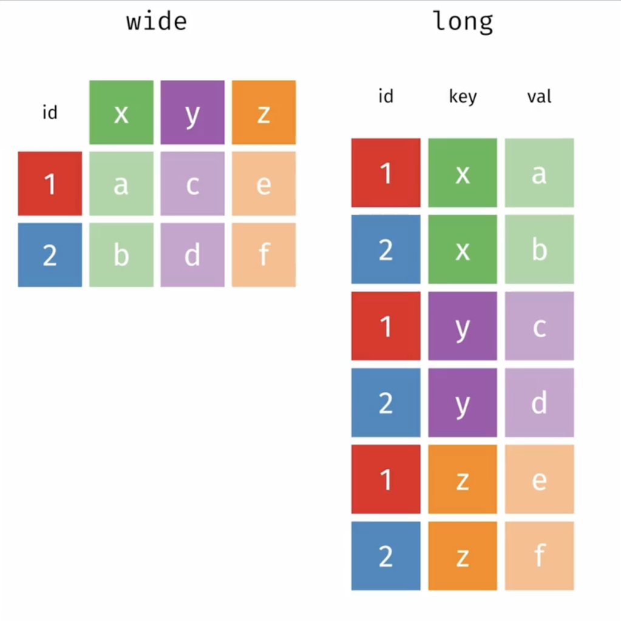

### Pivot longer

Let’s illustrate the utility of pivot_longer by summarizing

```r
scores <- read_csv('data/Part_2/13_scores_by_date.csv')

scores |>
  pivot_longer(cols = -date, #cols = 2:5 cols = contains('score')
               names_to = "score_category",
               values_to = "score")
```

```
# A tibble: 24 × 3
   date       score_category score
   <date>     <chr>          <dbl>
 1 2023-06-01 score_cat_A       10
 2 2023-06-01 score_cat_B        5
 3 2023-06-01 score_cat_C        9
 4 2023-06-01 score_cat_D        9
 5 2023-06-02 score_cat_A        5
 6 2023-06-02 score_cat_B        0
 7 2023-06-02 score_cat_C        2
 8 2023-06-02 score_cat_D        0
 9 2023-06-03 score_cat_A        7
10 2023-06-03 score_cat_B        7
# ℹ 14 more rows
```

```r
scores |>
  pivot_longer(cols = -date, #cols = 2:5 cols = contains('score')
               names_to = "score_category",
               values_to = "score") |>
  summarise(
    mean_score = mean(score),
    .by = score_category
  )
```

```
# A tibble: 4 × 2
  score_category mean_score
  <chr>               <dbl>
1 score_cat_A          6.5
2 score_cat_B          5.17
3 score_cat_C          4.67
4 score_cat_D          4.17
```

### Another example

This file needs to be rearrange before pivoting longer. Notice that `payment` the value column appears first.

```r
payments <-  read_csv('data/Part_2/14_payments.csv')

payments |>
  pivot_longer(
    cols = contains('date')
  )
```

```
# A tibble: 15 × 4
   utility     payment name               value
   <chr>         <dbl> <chr>              <date>
 1 heating       1271. last_payment_date  2023-06-04
 2 heating       1271. next_payment_date  2024-06-04
 3 heating       1271. final_payment_date NA
 4 phone         1436. last_payment_date  2023-06-11
 5 phone         1436. next_payment_date  2023-07-11
 6 phone         1436. final_payment_date 2024-06-11
 7 internet      1334. last_payment_date  2023-06-17
 8 internet      1334. next_payment_date  2023-07-17
 9 internet      1334. final_payment_date 2024-06-17
10 electricity   1486. last_payment_date  2023-06-16
11 electricity   1486. next_payment_date  2023-07-16
12 electricity   1486. final_payment_date 2024-06-16
13 rent          1672. last_payment_date  2023-06-11
14 rent          1672. next_payment_date  2023-07-11
15 rent          1672. final_payment_date NA
```

```r
#We need meaning names for the new columns

payments |>
  pivot_longer(
    cols = contains('date'),
    names_to = "payment_date",
    values_to = "date"
  )
```

```
# A tibble: 15 × 4
   utility     payment payment_date       date
   <chr>         <dbl> <chr>              <date>
 1 heating       1271. last_payment_date  2023-06-04
 2 heating       1271. next_payment_date  2024-06-04
 3 heating       1271. final_payment_date NA
 4 phone         1436. last_payment_date  2023-06-11
 5 phone         1436. next_payment_date  2023-07-11
 6 phone         1436. final_payment_date 2024-06-11
 7 internet      1334. last_payment_date  2023-06-17
 8 internet      1334. next_payment_date  2023-07-17
 9 internet      1334. final_payment_date 2024-06-17
10 electricity   1486. last_payment_date  2023-06-16
11 electricity   1486. next_payment_date  2023-07-16
12 electricity   1486. final_payment_date 2024-06-16
13 rent          1672. last_payment_date  2023-06-11
14 rent          1672. next_payment_date  2023-07-11
15 rent          1672. final_payment_date NA
```